```python
import pandas as pd
from datetime import datetime
import datetime as dt
import numpy as np
import matplotlib.pylab as plt
%matplotlib inline
from matplotlib.pylab import rcParams
rcParams['figure.figsize'] = 15, 6
from time import strptime
import seaborn as sns
from pandas.tseries.holiday import USFederalHolidayCalendar as calendar
from sklearn.model_selection import train_test_split
from sklearn.linear_model import LinearRegression
from sklearn.ensemble import RandomForestRegressor
from sklearn.metrics import mean_squared_error, mean_absolute_error ,r2_score
from matplotlib import rcParams
from scipy import stats
import statsmodels.api as sm
from pandas import Series
```

# Loading Data

```python
sales_data=pd.read_csv("SalesUnits.csv")
sales_data['date'] =pd.to_datetime(sales_data.WeekID)
date_main=pd.to_datetime(sales_data['date'], format='%b %d, %Y')
```

### Very simple data. Just dates and sales, let's take a look at the sales and see what we have through looking at the statistical information:

```python
sales_data.Sales.describe()
```

```
count    1.650000e+02
mean     1.115015e+06
std      1.397599e+06
min      2.391060e+05
25%      4.809760e+05
50%      6.304270e+05
75%      9.286940e+05
max      9.105197e+06
Name: Sales, dtype: float64
```

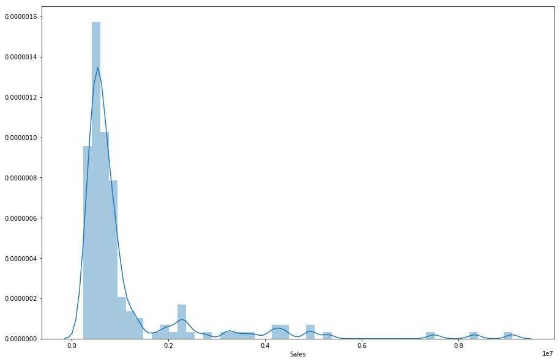

```python
plt.figure(figsize=(15,10))
sns.distplot(sales_data.Sales)
```

### alot of outliers. Data is skewed and so if we are thinking about a regression model, we have to think about a loss tat is not very senstive to outliers. Consider mean absolute error if you are thinking about regression model.

I am ML person, so first thing I think about is feature extraction, so I started to extract some features such as month, holiday, recent sales, etc.

```python
sales_data['month']=date_main.dt.month
sales_data['year']=date_main.dt.year
sales_data['month_name'] = sales_data['date'].dt.strftime('%b')
cal = calendar()
holidays = cal.holidays(start=sales_data['date'].min(), end=sales_data['date'].max())
sales_data['Holiday'] = sales_data['date'].isin(holidays)
```

# EXPLORATORY ANALYSIS

```python
yearly_sales=sales_data.groupby('year')['Sales'].mean()
monthly_sales=sales_data.groupby('month_name')['Sales'].mean()
```

Look at the trend of the sales in diffrent times like months and years

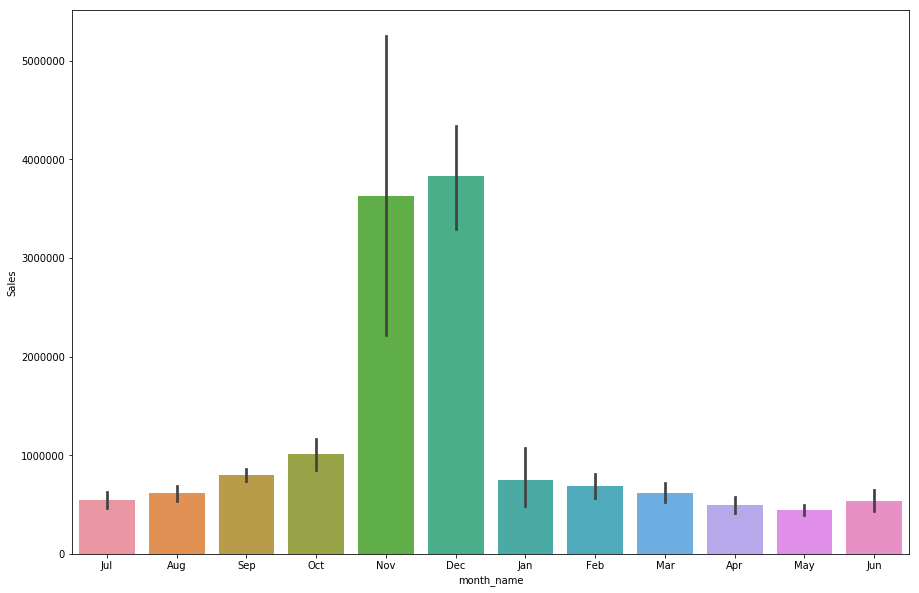

```python
plt.figure(figsize=(15,10))
ax = sns.barplot(x="month_name", y="Sales", data=sales_data)
```

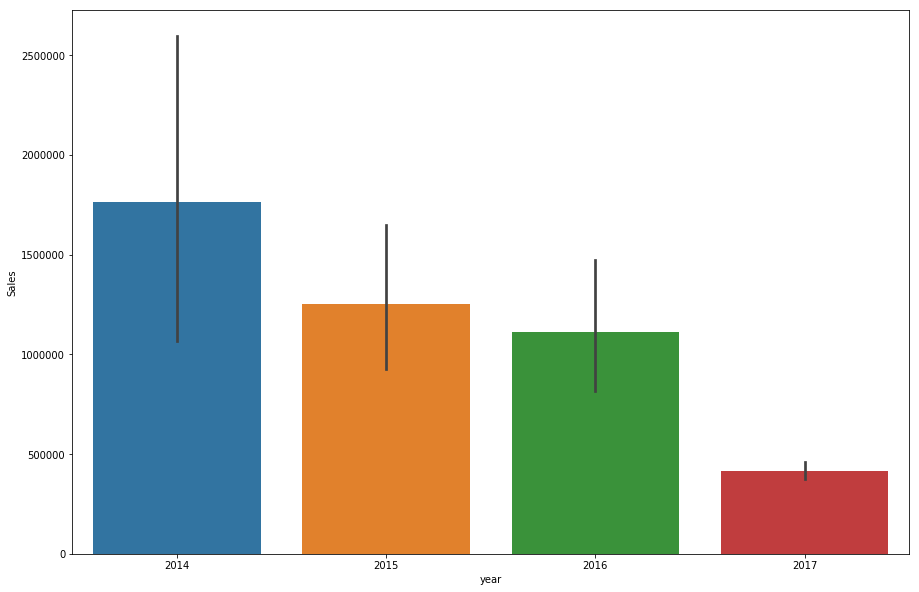

```python
plt.figure(figsize=(15,10))
ax = sns.barplot(x="year", y="Sales", data=sales_data)
```

### Seasonality during holidays, we see that in November and December the sales boosts. This shows some sort of seasonality. If we are thinking to make a forcasting model using ML, then month may be a good feature to predict sales.

```python
cal = calendar()
holidays = cal.holidays(start=df['date'].min(), end=df['date'].max())
df['Holiday'] = df['date'].isin(holidays)
```

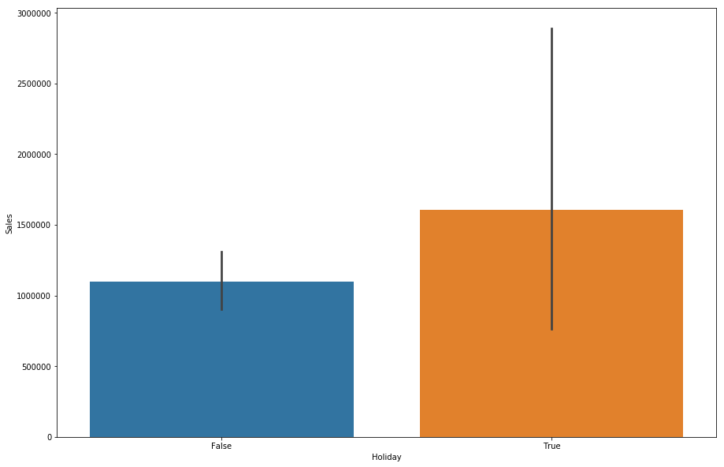

```python
plt.figure(figsize=(15,10))
ax = sns.barplot(x="Holiday", y="Sales", data=sales_data)
```

```python
x = sales_data[sales_data.columns.difference(['date', 'Sales'])]
y = sales_data.Sales
```

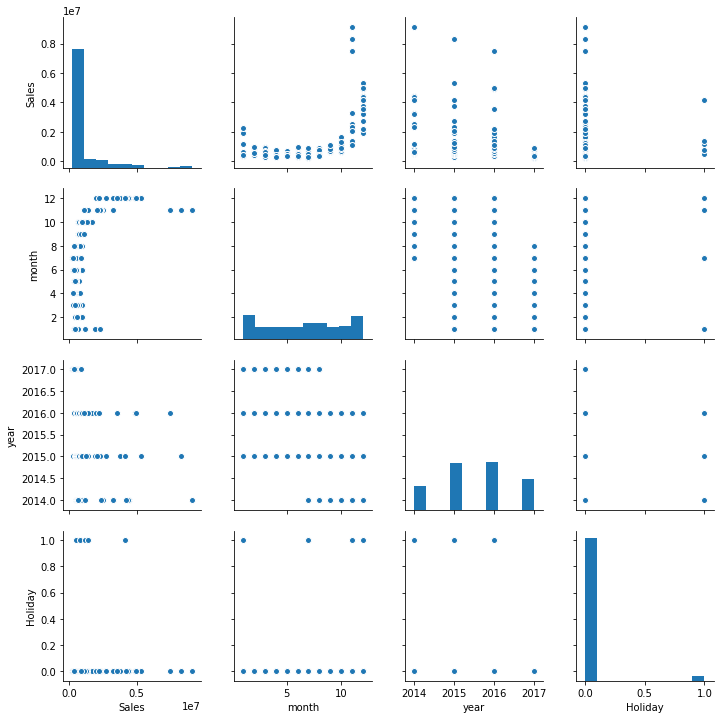

```python
sns.pairplot(sales_data);
```